# lab08

## Gain and phase of continuous time system's transfer function: the Bode plot

Find the gain and phase angle for angular frequencies 0 rad/s (d.c.), 2 rad/s and for very large frequencies if the system is characterised by the transfer function $$ H(s) = \dfrac{s+1}{s+2}\rightarrow |H(j\omega)|=\sqrt{\dfrac{\omega^2 + 1}{\omega^2 + 4}}\ ,\quad \angle H(j\omega)=\arctan\frac{\omega}{1} - \arctan\frac{\omega}{2} $$

[figure not shown]

$\omega = 0$ rad/s $\rightarrow$ {Gain} = 0.5, phase angle = 0$^\circ$ $\omega = 2$ rad/s $\rightarrow$ {Gain} =$\sqrt{\frac{5}{8}}\approx 0,79$, phase angle = $\arctan 2 - \arctan 1 = 18.4^\circ$ $\omega \rightarrow\infty$ rad/s $\rightarrow$ {Gain} $\rightarrow$ 1, phase angle = $\frac{\pi}{2} - \frac{\pi}{2}=0^\circ$

```
0.5 0.0 deg 0.7905694150420948 18.434948822922006 deg
```

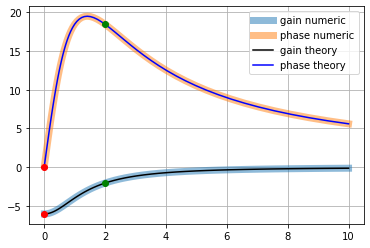

```python
from pylab import *
from scipy import signal
num, den = [1, 1], [1, 2]
o, gain, phase = signal.bode((num, den))
def gain_theory(o):
    return 20*log10(sqrt(o**2 + 1)/sqrt(o**2+4))
def phase_theory(o):
    return (arctan(o) - arctan(o/2))*180/pi
plot(o, gain           , linewidth=7, alpha=0.5, label='gain numeric') # o is omega in rad/s, gain in decibels
plot(o, phase          , linewidth=7, alpha=0.5, label='phase numeric') # phase in degrees
plot(o, gain_theory (o), 'k-'                  , label='gain theory'  )
plot(o, phase_theory(o), 'b-'                  , label='phase theory' )
plot([0], [gain_theory (0)], 'ro', [2], [gain_theory (2)], 'go')
plot([0], [phase_theory(0)], 'ro', [2], [phase_theory(2)], 'go')
grid()
legend()
print(10**(gain_theory(0)/20) , phase_theory (0),'deg', 10**(gain_theory(2)/20), phase_theory(2),'deg')
```

```python
o
```

```
array([ 0.01      ,  0.01072267,  0.01149757,  0.01232847,  0.01321941,
        0.01417474,  0.01519911,  0.01629751,  0.01747528,  0.01873817,
        0.02009233,  0.02154435,  0.0231013 ,  0.02477076,  0.02656088,
        0.02848036,  0.03053856,  0.03274549,  0.03511192,  0.03764936,
        0.04037017,  0.04328761,  0.04641589,  0.04977024,  0.05336699,
        0.05722368,  0.06135907,  0.06579332,  0.07054802,  0.07564633,
        0.08111308,  0.0869749 ,  0.09326033,  0.1       ,  0.10722672,
        0.1149757 ,  0.12328467,  0.13219411,  0.14174742,  0.15199111,
        0.16297508,  0.17475284,  0.18738174,  0.2009233 ,  0.21544347,
        0.23101297,  0.24770764,  0.26560878,  0.28480359,  0.30538555,
        0.32745492,  0.35111917,  0.37649358,  0.40370173,  0.43287613,
        0.46415888,  0.49770236,  0.53366992,  0.57223677,  0.61359073,
        0.65793322,  0.70548023,  0.75646333,  0.81113083,  0.869749  ,
        0.93260335,  1.        ,  1.07226722,  1.149757  ,  1.23284674,
        1.32194115,  1.41747416,  1.51991108,  1.62975083,  1.7475284 ,
        1.87381742,  2.009233  ,  2.15443469,  2.3101297 ,  2.47707636,
        2.65608778,  2.84803587,  3.05385551,  3.27454916,  3.51119173,
        3.76493581,  4.03701726,  4.32876128,  4.64158883,  4.97702356,
        5.33669923,  5.72236766,  6.13590727,  6.57933225,  7.05480231,
        7.56463328,  8.11130831,  8.69749003,  9.32603347, 10.        ])
```

```python
gain
```

```
array([-6.02027421, -6.02022544, -6.02016937, -6.02010489, -6.02003077,
       -6.01994555, -6.01984756, -6.01973491, -6.0196054 , -6.0194565 ,
       -6.0192853 , -6.01908849, -6.01886222, -6.01860209, -6.01830303,
       -6.01795923, -6.017564  , -6.01710965, -6.01658737, -6.01598699,
       -6.01529688, -6.01450364, -6.0135919 , -6.01254403, -6.01133975,
       -6.0099558 , -6.00836551, -6.00653827, -6.00443896, -6.00202736,
       -5.99925737, -5.9960762 , -5.99242344, -5.98822999, -5.9834169 ,
       -5.97789403, -5.97155858, -5.96429345, -5.95596546, -5.94642333,
       -5.9354956 , -5.92298835, -5.90868276, -5.89233264, -5.87366192,
       -5.85236221, -5.82809051, -5.80046729, -5.76907506, -5.73345776,
       -5.69312118, -5.64753486, -5.59613572, -5.53833401, -5.47352188,
       -5.40108505, -5.32041784, -5.23094179, -5.13212772, -5.02352105,
       -4.90476948, -4.77565199, -4.63610764, -4.48626223, -4.32645066,
       -4.15723267, -3.97940009, -3.79397365, -3.6021886 , -3.40546865,
       -3.20538936, -3.00363228, -2.80193275, -2.60202426, -2.40558294,
       -2.21417562, -2.02921462, -1.85192168, -1.68330275, -1.52413431,
       -1.37496095, -1.23610317, -1.10767371, -0.98960021, -0.88165209,
       -0.7834694 , -0.6945918 , -0.61448612, -0.54257145, -0.47824102,
       -0.42088053, -0.36988303, -0.32466027, -0.28465119, -0.24932761,
       -0.2181978 , -0.19080826, -0.16674404, -0.14562805, -0.12711966])
```

```python
phase
```

```
array([ 0.28646219,  0.30716133,  0.32935572,  0.35315326,  0.37866964,
        0.40602885,  0.43536378,  0.4668169 ,  0.50054084,  0.53669923,
        0.57546734,  0.61703301,  0.66159746,  0.70937621,  0.76060011,
        0.81551633,  0.87438951,  0.93750289,  1.00515954,  1.07768367,
        1.15542195,  1.23874494,  1.32804851,  1.42375536,  1.52631654,
        1.63621299,  1.75395706,  1.88009406,  2.01520367,  2.15990128,
        2.31483915,  2.4807074 ,  2.65823458,  2.84818791,  3.05137293,
        3.26863243,  3.50084457,  3.74891973,  4.01379611,  4.29643354,
        4.59780519,  4.9188868 ,  5.26064288,  5.62400932,  6.00987187,
        6.41903977,  6.85221401,  7.30994941,  7.79261024,  8.30031875,
        8.83289677,  9.38980047,  9.97004934, 10.5721508 , 11.19402313,
       11.83292011, 12.48536217, 13.14708003, 13.81297756, 14.47712169,
       15.13276697, 15.7724221 , 16.38796382, 16.97080113, 17.51208898,
       18.0029864 , 18.43494882, 18.80004037, 19.09124772, 19.30277528,
       19.43030083, 19.47117289, 19.42453434, 19.29136294, 19.07442514,
       18.77814722, 18.40841359, 17.97230788, 17.47781591, 16.9335113 ,
       16.34824402, 15.73084983, 15.08989494, 14.4334654 , 13.76900624,
       13.10321083, 12.44195735, 11.79028669, 11.15241462, 10.53177037,
        9.93105409,  9.35230624,  8.79698323,  8.26603446,  7.75997748,
        7.2789687 ,  6.82286816,  6.39129751,  5.98369097,  5.59933934])
```

```python
signal.bode?
```

[output not shown]

```python
# Let's create our own general Bode plot calculator
# and compare it to the one in the 'signal' package
def my_bode(transfer_function, omega = linspace(0.01, 10,100)):
    return omega,\
           20*log10(abs(transfer_function(1j*omega))),\
           180/pi*angle(transfer_function(1j*omega))
```

```python
H = lambda s: (s+1)/(s+2)
o1, gain1, phase1 = my_bode(H)
print(o1, gain1, phase1)
```

```
[ 0.01        0.11090909  0.21181818  0.31272727  0.41363636  0.51454545
  0.61545455  0.71636364  0.81727273  0.91818182  1.01909091  1.12
  1.22090909  1.32181818  1.42272727  1.52363636  1.62454545  1.72545455
  1.82636364  1.92727273  2.02818182  2.12909091  2.23        2.33090909
  2.43181818  2.53272727  2.63363636  2.73454545  2.83545455  2.93636364
  3.03727273  3.13818182  3.23909091  3.34        3.44090909  3.54181818
  3.64272727  3.74363636  3.84454545  3.94545455  4.04636364  4.14727273
  4.24818182  4.34909091  4.45        4.55090909  4.65181818  4.75272727
  4.85363636  4.95454545  5.05545455  5.15636364  5.25727273  5.35818182
  5.45909091  5.56        5.66090909  5.76181818  5.86272727  5.96363636
  6.06454545  6.16545455  6.26636364  6.36727273  6.46818182  6.56909091
  6.67        6.77090909  6.87181818  6.97272727  7.07363636  7.17454545
  7.27545455  7.37636364  7.47727273  7.57818182  7.67909091  7.78
  7.88090909  7.98181818  8.08272727  8.18363636  8.28454545  8.38545455
  8.48636364  8.58727273  8.68818182  8.78909091  8.89        8.99090909
  9.09181818  9.19272727  9.29363636  9.39454545  9.49545455  9.59636364
  9.69727273  9.79818182  9.89909091 10.        ] [-6.02027421 -5.98083896 -5.87843251 -5.7202801  -5.51657944 -5.27887193
 -5.01857223 -4.74592662 -4.46945726 -4.19580689 -3.92984676 -3.67492155
 -3.43314011 -3.2056576  -2.99292242 -2.79487886 -2.61112635 -2.44104052
 -2.28386265 -2.13876436 -2.00489305 -1.881403   -1.76747584 -1.66233338
 -1.56524488 -1.47553055 -1.39256234 -1.31576305 -1.24460421 -1.17860341
 -1.11732117 -1.06035773 -1.00734977 -0.95796734 -0.9119108  -0.86890808
 -0.82871209 -0.7910983  -0.7558626  -0.72281934 -0.6917995  -0.66264908
 -0.63522769 -0.60940716 -0.58507043 -0.56211043 -0.54042917 -0.51993686
 -0.50055113 -0.48219637 -0.46480308 -0.44830731 -0.43265019 -0.41777742
 -0.40363889 -0.39018835 -0.37738298 -0.3651832  -0.35355231 -0.3424563
 -0.33186357 -0.32174482 -0.31207275 -0.30282198 -0.29396888 -0.2854914
 -0.27736897 -0.2695824  -0.26211374 -0.2549462  -0.24806408 -0.24145265
 -0.23509813 -0.22898758 -0.22310884 -0.2174505  -0.21200184 -0.20675275
 -0.20169374 -0.19681586 -0.19211067 -0.18757021 -0.18318698 -0.17895387
 -0.1748642  -0.17091162 -0.16709014 -0.16339409 -0.15981809 -0.15635706
 -0.15300616 -0.14976083 -0.1466167  -0.14356966 -0.14061578 -0.13775135
 -0.13497281 -0.13227679 -0.12966009 -0.12711966] [ 0.28646219  3.1546973   5.91390951  8.47887236 10.78670317 12.80012709
 14.50584926 15.90983402 17.03148204 17.89815962 18.54081698 18.99087396
 19.27823646 19.43018811 19.4708963  19.42131574 19.2993284  19.12000898
 18.89594407 18.63756098 18.35344144 18.05060719 17.73477261 17.41056343
 17.08170348 16.75117244 16.42133804 16.09406621 15.77081248 15.4526975
 15.14056936 14.83505485 14.5366016  14.24551264 13.96197475 13.68608168
 13.41785313 13.1572503  12.90418854 12.65854773 12.42018068 12.18891996
 11.9645835  11.74697905 11.53590783 11.33116739 11.132554   10.93986445
 10.75289752 10.57145508 10.395343   10.22437177 10.058357    9.89711975
  9.74048673  9.58829046  9.4403693   9.29656748  9.15673501  9.02072763
  8.88840666  8.75963889  8.63429642  8.5122565   8.39340134  8.27761798
  8.16479807  8.0548377   7.94763724  7.84310117  7.74113787  7.64165952
  7.54458188  7.44982415  7.35730886  7.26696165  7.17871119  7.09248905
  7.00822952  6.92586951  6.84534848  6.76660825  6.68959293  6.61424884
  6.54052438  6.46836993  6.3977378   6.3285821   6.2608587   6.19452513
  6.12954049  6.06586545  6.00346208  5.94229387  5.88232566  5.82352352
  5.76585479  5.70928793  5.65379256  5.59933934]
```

[figure not shown]

```python
plot(o, gain           , linewidth=7, alpha=0.5, label='gain (signal.bode)') # o is omega in rad/s, gain in decibels
plot(o, phase          , linewidth=7, alpha=0.5, label='phase (signal.bode)') # phase in degrees
plot(o1, gain1, 'k-'                  , label='gain (my_bode)'  )
plot(o1, phase1, 'b-'                  , label='phase (my_bode)' )
legend()
```

## Power series recap:

$$ S_N = \sum_{n=0}^{N} r^n $$

Multiply by $r$: $$ rS_N = \sum_{n=0}^{N} r^{n+1} = \sum_{n=1}^{N+1} r^n=S_{N} + r^{N+1} - 1 $$

$$ (1-r)S_N = 1-r^{N+1} $$$$ \boxed{ S_N=\sum_{n=0}^{N}r^n=\frac{1-r^{N+1}}{1-r} } $$

If $|r|<1$, then $$ r^{N+1}\to 0, $$

so $$ \boxed{ \sum_{n=0}^{\infty}r^n=\frac{1}{1-r}, \qquad |r|<1 } $$

## Exercise

Calculate the $z$-transform of $$ u[n] = \begin{cases} 0\ , & n < 0\\ 1\ , & n\geqslant 0 \end{cases} $$

### Solution:

$$ U(z)=\sum_{n=-\infty}^{\infty} u[n]\,z^{-n} =\sum_{n=0}^{\infty} z^{-n} $$$$ U(z)=\sum_{n=0}^{\infty} (z^{-1})^n =\frac{1}{1-z^{-1}}, \quad |z|>1 $$$$ \boxed{ U(z)=\frac{1}{1-z^{-1}}=\frac{z}{z-1}, \quad \text{ROC: } |z|>1 } $$

## Exercise

Show that if sampled at intervals $T$ the $z$-transform of $x(t) = t$ is $\frac{Tz}{(z-1)^2}$;

### Solution

Sampling $x(t)=t$ at intervals $T$ gives $$ x[n]=x(nT)=nT,\qquad n\ge 0. $$

Therefore its $z$-transform is $$ X(z)=\sum_{n=0}^{\infty} nT z^{-n} =T\sum_{n=0}^{\infty} n z^{-n}. $$

Start from the geometric series: $$ \sum_{n=0}^{\infty} r^n=\frac{1}{1-r},\qquad |r|<1. $$

Differentiate with respect to $r$: $$ \sum_{n=1}^{\infty} n r^{n-1} = \frac{1}{(1-r)^2}. $$

Multiply by $r$: $$ \sum_{n=1}^{\infty} n r^n = \frac{r}{(1-r)^2}. $$

Now set $$ r=z^{-1}. $$

Then $$ \sum_{n=0}^{\infty} n z^{-n} = \frac{z^{-1}}{(1-z^{-1})^2}. $$

Hence $$ X(z) = T\frac{z^{-1}}{(1-z^{-1})^2}. $$

Finally, $$ T\frac{z^{-1}}{(1-z^{-1})^2} = T\frac{z^{-1}}{\left(\frac{z-1}{z}\right)^2} = T\frac{z^{-1}z^2}{(z-1)^2} = \boxed{ \frac{Tz}{(z-1)^2} } $$

with ROC: $$ \boxed{|z|>1.} $$

## Exercise

Show that if sampled at intervals $T$ the $z$-transform of $x(t) =e^{-at}$ is $\frac{z}{z-e^{-aT}}$

### Solution

Sampling $x(t)=e^{-at}$ at intervals $T$ gives $$ x[n]=x(nT)=e^{-anT}=\left(e^{-aT}\right)^n,\qquad n\ge 0. $$

Therefore its $z$-transform is $$ X(z)=\sum_{n=0}^{\infty} x[n]z^{-n} = \sum_{n=0}^{\infty} \left(e^{-aT}\right)^n z^{-n}. $$

Rewrite the terms: $$ X(z)=\sum_{n=0}^{\infty} \left(e^{-aT}z^{-1}\right)^n. $$

Using the geometric series formula, $$ \sum_{n=0}^{\infty} r^n=\frac{1}{1-r},\qquad |r|<1, $$

with $$ r=e^{-aT}z^{-1}, $$

we get $$ X(z)=\frac{1}{1-e^{-aT}z^{-1}}. $$

Equivalently, $$ \boxed{ X(z)=\frac{z}{z-e^{-aT}} } $$

with ROC: $$ \boxed{ |z|>e^{-aT} } $$

## Exercise

Show that if sampled at intervals $T$, the $z$-transform of $x(t)=\sin \omega t$ is $$ X_{\sin}(z)=\frac{z\sin\omega T}{z^2-2z\cos\omega T+1}, $$ and the $z$-transform of $x(t)=\cos \omega t$ is $$ X_{\cos}(z)=\frac{z(z-\cos\omega T)}{z^2-2z\cos\omega T+1}. $$

### Solution

Using the previous result for $x(t)=e^{-at}$, we may write $$ \mathcal{Z}\left\{e^{-anT}\right\} = \frac{z}{z-e^{-aT}}. $$

Now take $a=-i\omega$. Then $$ e^{-aT}=e^{i\omega T}, $$ so $$ \mathcal{Z}\left\{e^{i\omega nT}\right\} = \frac{z}{z-e^{i\omega T}}. $$

$$ \frac{z}{z-e^{i\omega T}}=\frac{z(z-e^{-i\omega T})}{(z-e^{i\omega T})(z-e^{-i\omega T})}. $$

Since $$ (z-e^{i\omega T})(z-e^{-i\omega T})=z^2-2z\cos\omega T+1,$$ we get $$\frac{z}{z-e^{i\omega T}}=\frac{z(z-e^{-i\omega T})}{z^2-2z\cos\omega T+1}.$$

Now use $$ e^{-i\omega T}=\cos\omega T-i\sin\omega T. $$ Therefore $$ \frac{z}{z-e^{i\omega T}}=\frac{z(z-\cos\omega T+i\sin\omega T)}{z^2-2z\cos\omega T+1}. $$ But $$ e^{i\omega nT}=\cos(\omega nT)+i\sin(\omega nT), $$ so the real part gives the cosine transform: $$ \boxed{X_{\cos}(z)=\frac{z(z-\cos\omega T)}{z^2-2z\cos\omega T+1}} $$ and the imaginary part gives the sine transform: $$ \boxed{X_{\sin}(z)=\frac{z\sin\omega T}{z^2-2z\cos\omega T+1}} $$

The ROC is $$ \boxed{|z|>1} $$ for the causal sampled sequences.

### Alternative Solution

$$ \mathcal{Z}\left\{e^{i\omega nT}\right\} = \frac{z}{z-e^{i\omega T}}. \qquad \mathcal{Z}\left\{e^{-i\omega nT}\right\} = \frac{z}{z-e^{-i\omega T}}. $$

Using Euler's formulas, $$ \cos(\omega nT)=\frac{e^{i\omega nT}+e^{-i\omega nT}}{2}, \qquad \sin(\omega nT)=\frac{e^{i\omega nT}-e^{-i\omega nT}}{2i}. $$

Putting the terms over a common denominator, $$ X_{\cos}(z) = \frac{z}{2} \frac{ (z-e^{-i\omega T})+(z-e^{i\omega T}) }{ (z-e^{i\omega T})(z-e^{-i\omega T}) }. $$

The numerator becomes $$ (z-e^{-i\omega T})+(z-e^{i\omega T}) = 2z-\left(e^{i\omega T}+e^{-i\omega T}\right) = 2z-2\cos\omega T. $$

The denominator becomes $$ (z-e^{i\omega T})(z-e^{-i\omega T}) = z^2-z\left(e^{i\omega T}+e^{-i\omega T}\right)+1 = z^2-2z\cos\omega T+1. $$

Hence $$ \boxed{ X_{\cos}(z) = \frac{z(z-\cos\omega T)}{z^2-2z\cos\omega T+1} } $$

Similarly, $$ X_{\sin}(z)= \frac{1}{2i} \left( \frac{z}{z-e^{i\omega T}}-\frac{z}{z-e^{-i\omega T}} \right). $$

Putting the terms over a common denominator, $$ X_{\sin}(z) = \frac{z}{2i} \frac{ (z-e^{-i\omega T})-(z-e^{i\omega T}) }{ (z-e^{i\omega T})(z-e^{-i\omega T}) }. $$

The numerator becomes $$ (z-e^{-i\omega T})-(z-e^{i\omega T}) = e^{i\omega T}-e^{-i\omega T} = 2i\sin\omega T. $$

Therefore $$ \boxed{ X_{\sin}(z) = \frac{z\sin\omega T}{z^2-2z\cos\omega T+1} } $$

## Exercise

If the input to a system, having a transfer function of $ 1 + 2z^{-1} - z^{-2} $, is a discrete unit step, show that the first four terms of the output sequence are 1, 3, 2, 2.

### Solution 1

$$ H(z)=1+2z^{-1}-z^{-2} $$

$ h[n]=\delta[n]+2\delta[n-1]-\delta[n-2] $, i.e., $h=\{1, 2, -1\}$ (impulse response)

The input is the discrete unit step:

For an LTI system,

$$ y[n]=h[n]*x[n] $$

Therefore,

$$ \begin{bmatrix} y[0]\\ y[1]\\ y[2]\\ y[3]\\ \vdots \end{bmatrix} = \begin{bmatrix} 1 & 0 & 0 & 0 & \dots\\ 2 & 1 & 0 & 0 & \dots\\ -1 & 2 & 1 & 0 & \dots\\ 0 & -1 & 2 & 1& \dots\\ & &\vdots & & \ddots \end{bmatrix} \begin{bmatrix} 1\\ 1\\ 1\\ 1\\ \vdots \end{bmatrix} = \begin{bmatrix} 1\\ 3\\ 2\\ 2\\ \vdots \end{bmatrix}. $$

### Solution 2

$$ H(z)=1+2z^{-1}-z^{-2} $$$$ x[n]=u[n] \qquad\Longrightarrow\qquad X(z)=\frac{1}{1-z^{-1}}, \qquad |z|>1 $$$$ Y(z)=H(z)X(z) = \left(1+2z^{-1}-z^{-2}\right)\frac{1}{1-z^{-1}} $$$$ Y(z)= \frac{1+2z^{-1}-z^{-2}}{1-z^{-1}} $$

Now divide the two polynomials in powers of $z^{-1}$:

$$ \begin{array}{rrrrrr|l} 1 & +2z^{-1} & -z^{-2} & +0z^{-3} & +0z^{-4} & \cdots & 1-z^{-1} \\ \hline &&&&&& 1+3z^{-1}+2z^{-2}+2z^{-3}+2z^{-4}+\cdots \\[1mm] 1 & -z^{-1} \\ \hline & 3z^{-1} & -z^{-2} \\ & 3z^{-1} & -3z^{-2} \\ \hline && 2z^{-2} & +0z^{-3} \\ && 2z^{-2} & -2z^{-3} \\ \hline &&& 2z^{-3} & +0z^{-4} \\ &&& 2z^{-3} & -2z^{-4} \\ \hline &&&& 2z^{-4} & \cdots \end{array} $$

Therefore,

$$ Y(z)=1+3z^{-1}+2z^{-2}+2z^{-3}+2z^{-4}+\cdots $$

Since

$$ Y(z)=\sum_{n=0}^{\infty} y[n]z^{-n}, $$

we read the samples directly:

$$ y[0]=1,\qquad y[1]=3,\qquad y[2]=2,\qquad y[3]=2. $$

Hence the first four terms are

$$ \boxed{1,\ 3,\ 2,\ 2}. $$

## Exercise

When a discrete signal ( 1, -2 ) is inputted to a processing system, the output sequence is ( 1, -5, 8, -4 ).

a. Derive the transfer function for the system.

b. Find the first three terms of the output sequence in response to the finite input sequence of ( 2, 2, 1 ).

### Solution 1

a. $$ x[n]=\{1,-2\} \qquad\Longrightarrow\qquad X(z)=1-2z^{-1} $$

$$ y[n]=\{1,-5,8,-4\} \qquad\Longrightarrow\qquad Y(z)=1-5z^{-1}+8z^{-2}-4z^{-3} $$$$ H(z)=\frac{Y(z)}{X(z)} = \frac{1-5z^{-1}+8z^{-2}-4z^{-3}}{1-2z^{-1}} $$

Now perform the division in powers of $z^{-1}$:

$$ \begin{array}{rrrrr|l} 1 & -5z^{-1} & +8z^{-2} & -4z^{-3} & +0z^{-4} & 1-2z^{-1}\\ \hline &&&&& 1-3z^{-1}+2z^{-2} \\[1mm] 1 & -2z^{-1} \\ \hline & -3z^{-1} & +8z^{-2} \\ & -3z^{-1} & +6z^{-2} \\ \hline && 2z^{-2} & -4z^{-3} \\ && 2z^{-2} & -4z^{-3} \\ \hline &&& 0 \end{array} $$

Therefore,

$$ \boxed{H(z)=1-3z^{-1}+2z^{-2}.} $$

b. $$ h[n]=\{1,-3,2\}, \qquad x[n]=\{2,2,1\}. $$

Using matrix-based convolution,

$$ y= \begin{bmatrix} 1 & 0 & 0 \\ -3 & 1 & 0 \\ 2 & -3 & 1 \\ 0 & 2 & -3 \\ 0 & 0 & 2 \end{bmatrix} \begin{bmatrix} 2\\ 2\\ 1 \end{bmatrix} = \begin{bmatrix} 2\\ -4\\ -1\\ 1\\ 2 \end{bmatrix}. $$

Therefore, the first three terms are

$$ \boxed{2,\,-4,\,-1}. $$

### Solution 2.

a.

$$ x[n]=\{1,-2\}, \qquad y[n]=\{1,-5,8,-4\}. $$

Assume the system impulse response has the form

$$ h[n]=\{h[0],h[1],h[2]\}. $$

Since

$$ y[n]=h[n]*x[n], $$

we can write the convolution in matrix form:

$$ \begin{bmatrix} y[0]\\ y[1]\\ y[2]\\ y[3] \end{bmatrix} = \begin{bmatrix} 1 & 0 & 0\\ -2 & 1 & 0\\ 0 & -2 & 1\\ 0 & 0 & -2 \end{bmatrix} \begin{bmatrix} h[0]\\ h[1]\\ h[2] \end{bmatrix} = \begin{bmatrix} 1\\ -5\\ 8\\ -4 \end{bmatrix}. $$

Therefore,

$$ h[0]=1, $$$$ -2h[0]+h[1]=-5 \quad\Longrightarrow\quad h[1]=-3, $$$$ -2h[1]+h[2]=8 \quad\Longrightarrow\quad h[2]=2. $$

Thus,

$$ h[n]=\{1,-3,2\}. $$

So the transfer function is

$$ \boxed{ H(z)=1-3z^{-1}+2z^{-2}. } $$

b.

$$ Y_1(z)=X_1(z)H(z), \qquad Y_2(z)=X_2(z)H(z). $$

Eliminating $H(z)$ gives

$$ \frac{Y_1(z)}{X_1(z)} = \frac{Y_2(z)}{X_2(z)}. $$

Therefore,

$$ X_1(z)Y_2(z)=X_2(z)Y_1(z). $$

In the time domain, multiplication in the $z$-domain corresponds to convolution:

$$ x_1[n]*y_2[n]=x_2[n]*y_1[n]. $$

For this problem,

$$ x_1[n]=\{1,-2\}, \qquad y_1[n]=\{1,-5,8,-4\}, \qquad x_2[n]=\{2,2,1\}. $$

On the right hand side since $x_2$ has length 3 and $y_1$ has length 4, the convolution $x_2*y_1$ has length 3+4-1=6.

$$ x_2*y_1 = \begin{bmatrix} 2&0&0&0\\ 2&2&0&0\\ 1&2&2&0\\ 0&1&2&2\\ 0&0&1&2\\ 0&0&0&1 \end{bmatrix} \begin{bmatrix} 1\\ -5\\ 8\\ -4 \end{bmatrix}= \begin{bmatrix} 2\\ -8\\ 7\\ 3\\ 0\\ -4 \end{bmatrix}.. $$

On the right hand side $x_1$ has length two so $y_2$ must have length 5 as 2 + 5 - 1=6.

Let

$$ \mathbf y_2= \begin{bmatrix} y_2[0]\\ y_2[1]\\ y_2[2]\\ y_2[3]\\ y_2[4] \end{bmatrix}. $$

Using the convolution matrix generated by $x_1=\{1,-2\}$:

$$ \begin{bmatrix} 1&0&0&0&0\\ -2&1&0&0&0\\ 0&-2&1&0&0\\ 0&0&-2&1&0\\ 0&0&0&-2&1\\ 0&0&0&0&-2 \end{bmatrix} \begin{bmatrix} y_2[0]\\ y_2[1]\\ y_2[2]\\ y_2[3]\\ y_2[4] \end{bmatrix} = \begin{bmatrix} 2\\ -8\\ 7\\ 3\\ 0\\ -4 \end{bmatrix}. $$

Solving by forward substitution:

$$ y_2[0]=2 $$$$ -2y_2[0]+y_2[1]=-8 \quad\Rightarrow\quad y_2[1]=-4 $$$$ -2y_2[1]+y_2[2]=7 \quad\Rightarrow\quad y_2[2]=-1 $$$$ -2y_2[2]+y_2[3]=3 \quad\Rightarrow\quad y_2[3]=1 $$$$ -2y_2[3]+y_2[4]=0 \quad\Rightarrow\quad y_2[4]=2 $$

Therefore,

$$ \mathbf y_2= \begin{bmatrix} 2\\ -4\\ -1\\ 1\\ 2 \end{bmatrix}. $$

So the first three terms are

$$ \boxed{2,\,-4,\,-1}. $$